# Cannabis

Marysol Novelo Lizárraga

08/03/21

Naturaleza: El cannabis es una planta de hojas verdes que puede llegar a medir seis metros de altura. Se da en lugares específicos que cuenten con las condiciones climáticas (cálidas y húmedas) y de suelo apropiadas, por ello se dice que México es un lugar indicado para su producción. Puede ser cultivada tanto en el exterior, como en el interior. Sin embargo, si se quiere comercializar con fines medicinales, requiere que se cuide la calidad de este en invernaderos con medidas que aseguren la calidad de esta.

Valor de uso: La planta cuenta con muchos componentes, siendo el más importante y de utilidad el THC por la gran psicoactividad que produce. Los derivados del cannabis se utilizan para fines recreativos, pero también como medicinas. Se sabe que puede tratar múltiples patologías como:cáncer, epilepsia, glaucoma, esclerosis múltiple, fibromialgia, dolor crónico, etc. Hoy en día, en México, se está estipulando su legalización recreativa, aunque ya lo es su uso medicinal. Sin embargo, falta más cooperación del gobierno para que promueva los reglamentos que falten para su impulso comercial.

Valor de cambio: Actualmente, tomando en cuenta que sigue siendo ilegal, se estima que la producción en México oscila entre 5, 250 y 6, 550 toneladas, mientras que la mano de obra estimada empleada en el cultivo y seca de marihuana es de 17,200 jefes de hogar y de por consiguiente 75.000 mexicanos dependientes de su cultivo. La marihuana mexicana es considerada como de calidad media/baja frente a la producida en Estados Unidos. Es por ello, que su competitividad con la marihuana de calidad está estancada. Sin embargo, recientemente se han incautado instalaciones para su cultivo que nos indica que se está prestando mayor atención en mejorar su concentración de THC (componente que define su calidad en el mercado). Pero, definitivamente con un libre comercio sería otra cosa; México tiene todas las condiciones necesarias para ser potencia en el mercado de Cannabis, podría ser gran exportador debido a sus buenas tierras, localización geográfica y a su mano de obra barata, perfectas para su producción y para la implantación de capital por parte de países consumidores que no cuenten con esa ventaja productiva.

Valor: México es el productor principal de marihuana a nivel mundial, es un negocio multimillonario que al año representa una ganancia de 8 mil millones de pesos para los narcotraficantes. Estos son datos de un comercio “ilegal”, pero es evidente que el mercado legal de cannabis tiene tanto potencial como el ilegal. Se estima que la regulación de la marihuana podría generar una industria de hasta 6 mil millones de dólares en México y que el cannabis medicinal tiene potencial de ingresos de 2 mil millones de dólares, con una creación de hasta 70,000 empleos. Estos últimos datos condicionados a la aprobación de la ley y a una mayor conciencia del impacto que tiene para la economía por parte del gobierno, lo que hoy en día significaría abrir un mercado enorme en México que apoyaría a la reactivación económica tras la crisis por la pandemia del COVID-19.

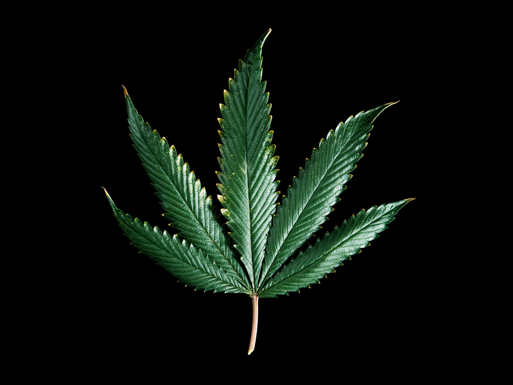

Fuente: https://media.wired.com/photos/595e4a3fe8898e3217b0b50c/master/w_2560%2Cc_limit/MarijuanaTA-92630655.jpg

## Bibliografía

1. Gob.mx. (2021). Retrieved 9 March 2021, from https://www.gob.mx/cms/uploads/attachment/file/85735/MIGUEL_MOLINA_M3.pdf.
2. Gob.mx. (2021). Retrieved 9 March 2021, from https://www.gob.mx/cms/uploads/attachment/file/55397/Nery_Rolando_Jimenez.pdf.
3. Cannabis. Infodrogas.org. (2021). Retrieved 9 March 2021, from https://www.infodrogas.org/drogas/cannabis.
4. Cannabis medicinal, un negocio millonario. El Financiero. (2021). Retrieved 9 March 2021, from https://www.elfinanciero.com.mx/economia/legalizacion-de-cannabis-dara-ingresos-por-2-mil-mdd-a-mexico-expertos.
5. Dinero, Q. (2021). El negocio de la Marihuana en México | Querido Dinero. Querido Dinero. Retrieved 9 March 2021, from https://www.queridodinero.com/articulos/el-negocio-de-la-marihuana-en-mexico.
6. Industria de la cannabis será clave en la reactivación económica de México. Publimetro México. (2021). Retrieved 9 March 2021, from https://www.publimetro.com.mx/mx/nacional/2021/02/27/cannabis-mexico-industria.html.
7. León A. Martínez 26 de noviembre de 2018, 1., Magaly Olivera, C., & Leonardo Nájera Rodríguez, C. (2021). ¿Qué productos de cannabis liberó la Cofepris y cuál es su uso?. El Economista. Retrieved 9 March 2021, from https://www.eleconomista.com.mx/arteseideas/Que-productos-de-cannabis-libero-la-Cofepris-y-cual-es-su-uso-20181126-0052.html.
8. User, S. (2021). La Planta de Cannabis. Cannabismedicinal.com.ar. Retrieved 9 March 2021, from https://www.cannabismedicinal.com.ar/cannabis-medicinal/cultivos1/147-planta-cannabis.